# (PSL) Coding Assignment 4

## Team members:

- Jesse Anderson - jander98
- Ailing Li - ailingl2
- Kevin Nguyen - kn28

### Contributions

- **Contribution from Jesse**
  - Tasks completed: Completed Part II and, for Part I, assisted with debugging, added 100 iterations, and created a graph.
- **Contribution from Ailing**
  - Tasks completed: Part I: Worked on the E-step and M-step, and assembled the draft of the final version of the assignment.
- **Contribution from Kevin**
  - Tasks completed: Part I: Worked on the loglike and myEM

## Part I: Gaussian Mixtures

**Objective**

Implement the EM algorithm from scratch for a p-dimensional Gaussian mixture model with G components:
$$\sum_{k=1}^{G} p_k \cdot N(x; \mu_k, \Sigma)$$

**Requirements**

Your implementation should consist of four functions:

- **E-step function**: This function should return an $n \times G$ matrix, where the $(i,j)$th entry represents the conditional probability $P(Z_i = k | x_i)$. Here $i$ ranges from 1 to $n$ and $k$ ranges from 1 to $G$.
- **M-step function**: This function should return the updated parameters for the Gaussian mixture model.
- **loglik function**: This function computes the log-likelihood of the data given the parameters.
- **myEM function (main function)**: Inside this function, you can call the E-step and M-step functions. The function should take the following inputs and return the estimated parameters and log-likelihood (via the loglik function):
  - **Input**:
    - data: The dataset.
    - G: The number of components. Although your code will be tested with $G = 2$ and $G = 3$, it should be able to handle any value of $G$ (you can, of course, ignore the case where $G > n$).
    - Initial parameters.
    - itmax: The number of iterations.
  - **Output**:
    - prob: A $G$-dimensional probability vector $(p_1, \ldots, p_G)$.
    - mean: A $p \times G$ matrix with the $k$-th column being $\mu_k$, the $p$-dimensional mean for the $k$-th Gaussian component.
    - Sigma: A $p \times p$ covariance matrix $\Sigma$ shared by all $G$ components.
    - loglik: A number equal to $\sum_{i=1}^{n} \log \left( \sum_{k=1}^{G} p_k \cdot N(x; \mu_k, \Sigma) \right)$.

```r
Estep = function(data, pi_k, mu_k, Sigma) {
  n = nrow(data)
  G = length(pi_k)
  p = ncol(data)

  # Precompute constants
  inv_sigma = solve(Sigma)

  # Init log-density matrix
  log_density_matrix = matrix(0, nrow = n, ncol = G)

  log_density_matrix = sapply(1:G, function(k) {
    # Compute diff = data - mu_k[k, ]
    diff = sweep(data, 2, mu_k[k, ], "-")

    # Compute exponent = rowSums((diff %*% inv_sigma) * diff)
    exponent = rowSums((diff %*% inv_sigma) * diff)

    density = log(pi_k[k]) - 0.5 * exponent
    return(density)
  })

  # Use log-sum-exp to compute the posterior probabilities
  max_log_density = apply(log_density_matrix, 1, max)
  density_matrix = exp(log_density_matrix - max_log_density)
  row_sums = rowSums(density_matrix)
  posterior = density_matrix / row_sums

  return(posterior)
}
```

```r
#Maximization Step: optimizing the covariance matrix
Mstep = function(data, posterior) {
  n = nrow(data)
  G = ncol(posterior)
  p = ncol(data)

  total_posterior = colSums(posterior)

  # Update mixing coefficients
  pi_k_new = total_posterior / n

  # Update means
  mu_k_new = (t(posterior) %*% data) / total_posterior  # G x p

  # Update shared covariance matrix Sigma
  Sigma_new = matrix(0, nrow = p, ncol = p)

  for (k in 1:G) {
    #comp weighted diff
    diff = sweep(data, 2, mu_k_new[k, ], "-")
    weighted_diff = posterior[, k] * diff
    Sigma_new = Sigma_new + t(weighted_diff) %*% diff
  }

  # Divide by n to get the average
  Sigma_new = Sigma_new / n

  return(list(pi_k = pi_k_new, mu_k = mu_k_new, Sigma = Sigma_new))
}
```

```r
# loglik Function: Compute log-likelihood with log-sum-exp
loglik = function(data, pi_k, mu_k, Sigma) {
  n = nrow(data)
  G = length(pi_k)
  p = ncol(data)
  inv_sigma = solve(Sigma)
  det_sigma = det(Sigma)

  if (!is.finite(det_sigma) || det_sigma <= 0) {
    stop("Covariance matrix is not positive-definite.")
  }
  coef = -0.5 * (p * log(2 * pi) + log(det_sigma))

  # Init log-likelihood matrix
  log_likelihood_matrix = matrix(0, nrow = n, ncol = G)

  for (k in 1:G) {
    # comp diff = data - mu_k[k, ]
    diff = sweep(data, 2, mu_k[k, ], "-")

    # comp exponent
    exponent = rowSums((diff %*% inv_sigma) * diff)

    # comp log-density
    log_density = log(pi_k[k]) + coef - 0.5 * exponent

    # Store in the matrix
    log_likelihood_matrix[, k] = log_density
  }

  # comp the total log-likelihood using log-sum-exp
  max_log_density = apply(log_likelihood_matrix, 1, max)
  total_loglik = sum(max_log_density + log(rowSums(exp(log_likelihood_matrix - max_log_density))))

  return(total_loglik)
}

myEM = function(data, G, pi_k_init, mu_k_init, Sigma_init, itmax, tol = 1e-6) {
  # Init param
  pi_k = pi_k_init
  mu_k = mu_k_init
  Sigma = Sigma_init

  # Inite log-likelihood storage
  log_lik_values = numeric(itmax)

  for (iter in 1:itmax) {
    # E-step: comp posterior probabilities
    posterior = Estep(data, pi_k, mu_k, Sigma)

    # M-step: Update parameters
    params = Mstep(data, posterior)
    pi_k = params$pi_k
    mu_k = params$mu_k
    Sigma = params$Sigma

    # comp log-likelihood
    log_lik = loglik(data, pi_k, mu_k, Sigma)
    log_lik_values[iter] = log_lik

    # Check for convergence
    if (iter > 1 && abs(log_lik_values[iter] - log_lik_values[iter - 1]) < tol) {
      log_lik_values = log_lik_values[1:iter]
      cat("Convergence reached at iteration:", iter, "\n")
      break
    }
  }

  result = list(
    prob = pi_k,
    mean = mu_k,
    Sigma = Sigma,
    loglik = log_lik_values
  )

  return(result)
}

# Custom print function
print_results = function(prob, mean_values, sigma, loglik) {
  cat("prob\n")
  print(prob)
  cat("\nmean\n")
  print(mean_values)
  cat("\nSigma\n")
  print(sigma)
  cat("\nloglik\n")
  print(loglik)
}
```

## Part I: Testing

Test your code with the provided dataset, [faithful.dat], with both G = 2 and G = 3.

**For the case when G = 2**, set your initial values as follows:

- p1 = 10/n, p2 = 1 − p1.
- µ1 = the mean of the first 10 samples; µ2 = the mean of the remaining samples.
- Calculate Σ as:

$$\frac{1}{n} \left[ [\sum_{i=1}^{10} (x_i - \mu_1)(x_i - \mu_1)^t +
\sum_{i=11}^{n} (x_i - \mu_2)(x_i - \mu_2)^t \right]$$

```r
# Load the data
# data prep and param init
data("faithful")
data_matrix = as.matrix(faithful[, c("eruptions", "waiting")])
n = nrow(data_matrix)

#init param for G = 2
G2 = 2
p1_G2 = 10 / n
p2_G2 = 1 - p1_G2
pi_k_init_G2 = c(p1_G2, p2_G2)


mu1_G2 = colMeans(data_matrix[1:10, ])                # Mean of the first 10 samples
mu2_G2 = colMeans(data_matrix[11:n, ])                # Mean of the remaining samples
mu_k_init_G2 = matrix(c(mu1_G2, mu2_G2), nrow = 2, byrow = TRUE)  # Combine means into a matrix

Sigma1 = matrix(0, nrow = 2, ncol = 2)
Sigma2 = matrix(0, nrow = 2, ncol = 2)

for (i in 1:10) {
  x_i = data_matrix[i, ]
  Sigma1 = Sigma1 + (x_i - mu1_G2) %*% t(x_i - mu1_G2)
}

# Compute contributions from cluster 2
for (i in 11:n) {
  x_i = data_matrix[i, ]
  Sigma2 = Sigma2 + (x_i - mu2_G2) %*% t(x_i - mu2_G2)
}

Sigma_init_G2 = (Sigma1 + Sigma2 ) / n

#init param for G = 3
G3 = 3
p1_G3 = 10 / n
p2_G3 = 20 / n
p3_G3 = 1 - p1_G3 - p2_G3
pi_k_init_G3 = c(p1_G3, p2_G3, p3_G3)

mu1_G3 = colMeans(data_matrix[1:10, ])
mu2_G3 = colMeans(data_matrix[11:30, ])
mu3_G3 = colMeans(data_matrix[31:n, ])
mu_k_init_G3 = rbind(mu1_G3, mu2_G3, mu3_G3)  # G x p

diff1_G3 = sweep(data_matrix[1:10, ], 2, mu1_G3, "-")
diff2_G3 = sweep(data_matrix[11:30, ], 2, mu2_G3, "-")
diff3_G3 = sweep(data_matrix[31:n, ], 2, mu3_G3, "-")
Sigma_init_G3 = (t(diff1_G3) %*% diff1_G3 +
                   t(diff2_G3) %*% diff2_G3 +
                   t(diff3_G3) %*% diff3_G3) / n

# Run EM algo for G = 2

# Run for 20 iter
em_result_G2_20 = myEM(
  data = data_matrix,
  G = G2,
  pi_k_init = pi_k_init_G2,
  mu_k_init = mu_k_init_G2,
  Sigma_init = Sigma_init_G2,
  itmax = 20,
  tol = 1e-6
)
#run 100
em_result_G2_100 = myEM(
  data = data_matrix,
  G = G2,
  pi_k_init = pi_k_init_G2,
  mu_k_init = mu_k_init_G2,
  Sigma_init = Sigma_init_G2,
  itmax = 100,
  tol = 1e-6
)

#Rin EM for G=3
em_result_G3_20 = myEM(
  data = data_matrix,
  G = G3,
  pi_k_init = pi_k_init_G3,
  mu_k_init = mu_k_init_G3,
  Sigma_init = Sigma_init_G3,
  itmax = 20,
  tol = 1e-6
)

em_result_G3_100 = myEM(
  data = data_matrix,
  G = G3,
  pi_k_init = pi_k_init_G3,
  mu_k_init = mu_k_init_G3,
  Sigma_init = Sigma_init_G3,
  itmax = 100,
  tol = 1e-6
)
```

Run your EM implementation with **20** iterations. Your results from myEM are expected to look like the following. (Even though the algorithm has not yet reached convergence, matching the expected results below serves as a validation that your code is functioning as intended.)

```r
cat("---- Results for G = 2 after 20 Iterations ----\n")
```

```
## ---- Results for G = 2 after 20 Iterations ----
```

```r
# re-oragnize expected mean to match with instruction result
em_result_G2_20_expected = matrix(c(em_result_G2_20$mean[1, 1], em_result_G2_20$mean[1, 2],
                                  em_result_G2_20$mean[2, 1], em_result_G2_20$mean[2, 2]), nrow = 2)
rownames(em_result_G2_20_expected) = c("eruptions", "waiting")

print_results(em_result_G2_20$prob, em_result_G2_20_expected,
              em_result_G2_20$Sigma, em_result_G2_20$loglik[length(em_result_G2_20$loglik)])
```

```
## prob
## [1] 0.04297883 0.95702117
##
## mean
##                [,1]     [,2]
## eruptions  3.495642  3.48743
## waiting   76.797892 70.63206
##
## Sigma
##           eruptions   waiting
## eruptions  1.297936  13.92434
## waiting   13.924336 182.58009
##
## loglik
## [1] -1289.569
```

**For the case when G = 3**, set your initial values as follows:

- p1 = 10/n, p2 = 20/n, p3 = 1 − p1 − p2
- $\mu_1 = \frac{1}{n} \sum_{i=1}^{10} (x_i)$, the mean of the first 10 samples; $\mu_2 = \frac{1}{20} \sum_{i=11}^{30} (x_i)$, the mean of the next 20 samples; $\mu_3$ is the mean of the remaining samples.
- Calculate Σ as
  $$\frac{1}{n} \left[
  \sum_{i=1}^{10} (x_i - \mu_1)(x_i - \mu_1)^t +
  \sum_{i=11}^{30} (x_i - \mu_2)(x_i - \mu_2)^t +
  \sum_{i=31}^{n} (x_i - \mu_3)(x_i - \mu_3)^t
  \right]$$

Run your EM implementation with 20 iterations.

```r
cat("\n---- Results for G = 3 after 20 Iterations ----\n")
```

```
##
## ---- Results for G = 3 after 20 Iterations ----
```

```r
# re-oragnize expected mean to match with instruction result
em_result_G3_20_expected = matrix(c(em_result_G3_20$mean[1, 1], em_result_G3_20$mean[1, 2],
                                  em_result_G3_20$mean[2, 1], em_result_G3_20$mean[2, 2]), nrow = 2)
rownames(em_result_G3_20_expected) = c("eruptions", "waiting")

print_results(em_result_G3_20$prob, em_result_G3_20$mean,
              em_result_G3_20$Sigma, em_result_G3_20$loglik[length(em_result_G3_20$loglik)])
```

```
## prob
## [1] 0.04363422 0.07718656 0.87917922
##
## mean
##      eruptions  waiting
## [1,]  3.510069 77.10564
## [2,]  2.816167 63.35753
## [3,]  3.545641 71.25085
##
## Sigma
##           eruptions   waiting
## eruptions  1.260158  13.51154
## waiting   13.511538 177.96419
##
## loglik
## [1] -1289.351
```

Additional result after ran the EM implementation with 100 iterations for G = 2 and G = 3

```r
cat("\n---- Results for G = 2 after 100 Iterations ----\n")
```

```
##
## ---- Results for G = 2 after 100 Iterations ----
```

```r
# re-oragnize expected mean to match with instruction result
em_result_G2_100_expected = matrix(c(em_result_G2_100$mean[1, 1], em_result_G2_100$mean[1, 2],
                                  em_result_G2_100$mean[2, 1], em_result_G2_100$mean[2, 2]), nrow = 2)
rownames(em_result_G2_100_expected) = c("eruptions", "waiting")

print_results(em_result_G2_100$prob, em_result_G2_100$mean,
              em_result_G2_100$Sigma, em_result_G2_100$loglik[length(em_result_G2_100$loglik)])
```

```
## prob
## [1] 0.2263964 0.7736036
##
## mean
##      eruptions  waiting
## [1,]  3.501349 77.36274
## [2,]  3.483813 69.00487
##
## Sigma
##           eruptions   waiting
## eruptions  1.297885  13.90075
## waiting   13.900750 171.90951
##
## loglik
## [1] -1287.743
```

```r
cat("\n---- Results for G = 3 after 100 Iterations ----\n")
```

```
##
## ---- Results for G = 3 after 100 Iterations ----
```

```r
# re-oragnize expected mean to match with instruction result
em_result_G3_100_expected = matrix(c(em_result_G3_100$mean[1, 1], em_result_G3_100$mean[1, 2],
                                  em_result_G3_100$mean[2, 1], em_result_G3_100$mean[2, 2]), nrow = 2)
rownames(em_result_G3_100_expected) = c("eruptions", "waiting")

print_results(em_result_G3_100$prob, em_result_G3_100$mean,
              em_result_G3_100$Sigma, em_result_G3_100$loglik[length(em_result_G3_100$loglik)])
```

```
## prob
## [1] 0.1682570 0.3563758 0.4753672
##
## mean
##      eruptions  waiting
## [1,]  3.797148 77.46323
## [2,]  2.037609 54.49122
## [3,]  4.465457 80.87217
##
## Sigma
##            eruptions    waiting
## eruptions 0.07799746  0.4700086
## waiting   0.47000855 33.6700718
##
## loglik
## [1] -1126.316
```

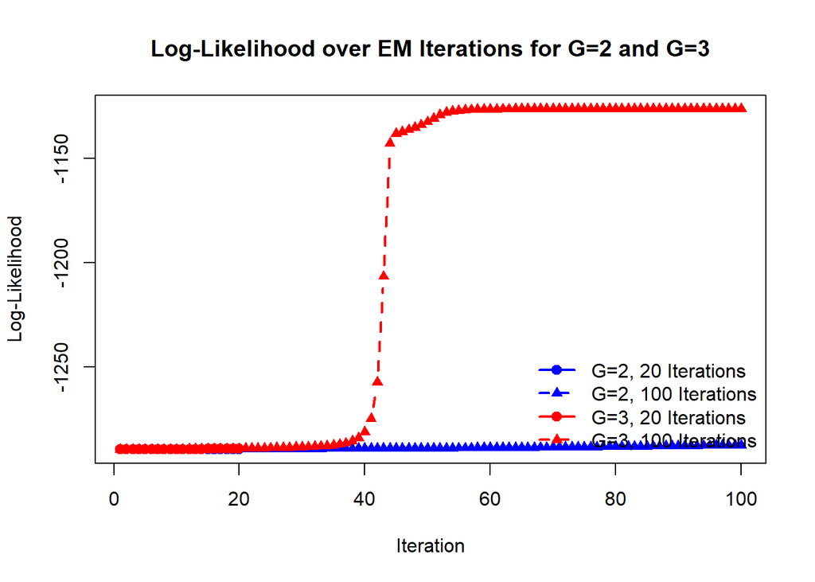

```r
#Plotting Log-Likelihoods

# Extract log-likelihoods
ll_G2_20 = em_result_G2_20$loglik
ll_G2_100 = em_result_G2_100$loglik
ll_G3_20 = em_result_G3_20$loglik
ll_G3_100 = em_result_G3_100$loglik

# Determine the maximum number of iterations among all runs
max_iter = max(length(ll_G2_20), length(ll_G2_100), length(ll_G3_20), length(ll_G3_100))

# Initialize the plot
plot(1:max_iter,
     type = "n",
     ylim = range(c(ll_G2_20, ll_G2_100, ll_G3_20, ll_G3_100)),
     xlab = "Iteration",
     ylab = "Log-Likelihood",
     main = "Log-Likelihood over EM Iterations for G=2 and G=3")

# Plot Log-Likelihoods for G = 2 (20 Iterations)
lines(1:length(ll_G2_20), ll_G2_20, type = "b", col = "blue", pch = 19, lwd = 2, lty = 1)

# Plot Log-Likelihoods for G = 2 (100 Iterations)
lines(1:length(ll_G2_100), ll_G2_100, type = "b", col = "blue", pch = 17, lwd = 2, lty = 2)

# Plot Log-Likelihoods for G = 3 (20 Iterations)
lines(1:length(ll_G3_20), ll_G3_20, type = "b", col = "red", pch = 19, lwd = 2, lty = 1)

# Plot Log-Likelihoods for G = 3 (100 Iterations)
lines(1:length(ll_G3_100), ll_G3_100, type = "b", col = "red", pch = 17, lwd = 2, lty = 2)

legend("bottomright",
       legend = c("G=2, 20 Iterations", "G=2, 100 Iterations",
                  "G=3, 20 Iterations", "G=3, 100 Iterations"),
       col = c("blue", "blue", "red", "red"),
       pch = c(19, 17, 19, 17),
       lty = c(1, 2, 1, 2),
       lwd = 2,
       bty = "n")
```

```r
print(em_result_G2_20$loglik[length(em_result_G2_20$loglik)], digits = 10)
```

```
## [1] -1289.569355
```

```r
print(em_result_G2_100$loglik[length(em_result_G2_100$loglik)], digits = 10)
```

```
## [1] -1287.743204
```

```r
print(em_result_G3_20$loglik[length(em_result_G3_20$loglik)], digits = 10)
```

```
## [1] -1289.350959
```

```r
print(em_result_G3_100$loglik[length(em_result_G3_100$loglik)], digits = 10)
```

```
## [1] -1126.315961
```

Part I conclusion: The log-likelihood results suggest that the model with 3 components and 100 interations leads a better fit for the faithful dataset by increasing both the number of components and iterations.

## Part II: HMM

**Objective**

Implement the Baum-Welch (i.e., EM) algorithm and the Viterbi algorithm **from scratch** for a Hidden Markov Model (HMM) that produces an outcome sequence of discrete random variables with three distinct values.

A quick review on parameters for Discrete HMM:

- **mx**: Count of distinct values X can take.
- **mz**: Count of distinct values Z can take.
- **w**: An mz-by-1 probability vector representing the initial distribution for $Z_1$.
- **A**: The mz-by-mz transition probability matrix that models the progression from $Z_t$ to$Z_{t+1}$.
- **B**: The mz-by-mx emission probability matrix, indicating how X is produced from $Z$.

Focus on updating the parameters **A** and **B** in your algorithm. The value for mx is given and you’ll specify mz

For w, initiate it uniformly but refrain from updating it within your code. The reason for this is that w denotes the distribution of $Z_1$ and we only have a single sample. It’s analogous to estimating the likelihood of a coin toss resulting in heads by only tossing it once. Given the scant information and the minimal influence on the estimation of other parameters, we can skip updating it.

**Baum-Welch Algorithm**

The Baum-Welch Algorihtm is the EM algorithm for the HMM. Create a function named **BW_onestep** designed to carry out the E-step and M-step. This function should then be called iteratively within **myBW**.

- **BW_onstep**:
  - **Input**:
    - data: a T-by-1 sequence of observations
    - Current parameter values
  - **Output**:
    - Updated parameters: A and B

Please refer to formulas provided on Pages 7, 10, 14-16 in [lec_W7.2_HMM](https://liangfgithub.github.io/Notes/lec_W7.2_HMM.pdf)

```r
# Function for Baum-Welch One Step (E-step and M-step)
BW_onestep = function(data, A, B, w) {
  T = length(data)
  mz = nrow(A)
  mx = ncol(B)

  # Forward probabilities with scaling
  alpha = matrix(0, nrow=T, ncol=mz)
  c = numeric(T)  # Scaling factors
  alpha[1, ] = w * B[, data[1]]
  c[1] = sum(alpha[1, ])
  alpha[1, ] = alpha[1, ] / c[1]
  for (t in 2:T) {
    for (j in 1:mz) {
      alpha[t, j] = sum(alpha[t - 1, ] * A[, j]) * B[j, data[t]]
    }
    c[t] = sum(alpha[t, ])
    alpha[t, ] = alpha[t, ] / c[t]
  }

  # Backward probabilities with scaling
  beta = matrix(0, nrow=T, ncol=mz)
  beta[T, ] = 1 / c[T]
  for (t in (T - 1):1) {
    for (j in 1:mz) {
      beta[t, j] = sum(A[j, ] * B[, data[t + 1]] * beta[t + 1, ]) / c[t]
    }
  }

  # E-step: Calculate xi and gamma
  xi = array(0, dim=c(T - 1, mz, mz))
  gamma = matrix(0, nrow=T, ncol=mz)
  for (t in 1:(T - 1)) {
    denom = sum(alpha[t, ] * beta[t, ])
    for (i in 1:mz) {
      gamma[t, i] = alpha[t, i] * beta[t, i] / denom
      for (j in 1:mz) {
        xi[t, i, j] = alpha[t, i] * A[i, j] * B[j, data[t + 1]] * beta[t + 1, j]
      }
    }
    xi[t, , ] = xi[t, , ] / sum(xi[t, , ])
  }
  gamma[T, ] = alpha[T, ] / sum(alpha[T, ])

  # M-step: Update A and B
  A_new = matrix(0, nrow=mz, ncol=mz)
  for (i in 1:mz) {
    denom = sum(gamma[-T, i])
    for (j in 1:mz) {
      A_new[i, j] = sum(xi[, i, j]) / denom
    }
  }

  B_new = matrix(0, nrow=mz, ncol=mx)
  for (j in 1:mz) {
    denom = sum(gamma[, j])
    for (k in 1:mx) {
      B_new[j, k] = sum(gamma[data == k, j]) / denom
    }
  }

  # Ensure no zero probabilities
  B_new[B_new == 0] = .Machine$double.eps

  list(A=A_new, B=B_new)
}

# Forward pass with scaling (helper function)
forward_pass = function(data, A, B, w) {
  # data: Sequence of observed data
  # A: Transition matrix
  # B: Emission matrix
  # w: Initial state probabilities

  T = length(data)  # Length of observed data
  mz = nrow(A)  # Number of hidden states
  alpha = matrix(0, nrow=T, ncol=mz)  # Matrix to store forward probabilities
  c = numeric(T)  # Scaling factors to prevent underflow
  alpha[1, ] = w * B[, data[1]]  # Initialization step
  c[1] = sum(alpha[1, ])  # Compute scaling factor for first time step
  alpha[1, ] = alpha[1, ] / c[1]  # Scale alpha to avoid underflow

  # Forward pass
  for (t in 2:T) {
    for (j in 1:mz) {
      alpha[t, j] = sum(alpha[t - 1, ] * A[, j]) * B[j, data[t]]
    }
    c[t] = sum(alpha[t, ])  # Compute scaling factor
    alpha[t, ] = alpha[t, ] / c[t]  # Scale alpha
  }
  list(alpha=alpha, c=c)  # Return alpha and scaling factors
}

# Func compute KL divergence between two probability distributions
kl_divergence = function(p, q) {
  # Ensure no zero probabilities to avoid log(0)
  p = p + .Machine$double.eps
  q = q + .Machine$double.eps
  sum(p * log(p / q))
}

# Baum-Welch Algorithm
myBW = function(data, A, B, w, iterations=100) {
  expected_A = matrix(c(0.49793938, 0.50206062, 0.44883431, 0.55116569), nrow=2, byrow=TRUE)
  expected_B = matrix(c(0.22159897, 0.20266127, 0.57573976, 0.34175148, 0.17866665, 0.47958186), nrow=2, byrow=TRUE)

  log_likelihoods = numeric(iterations)
  kl_divergences = numeric(iterations)

  for (i in 1:iterations) {
    params = BW_onestep(data, A, B, w)
    A = params$A
    B = params$B

    #Calc log-likelihood for current parameters
    forward_result = forward_pass(data, A, B, w)
    log_likelihood = sum(log(forward_result$c))  # Sum of log scaling factors gives log-likelihood
    log_likelihoods[i] = log_likelihood

    #Calc  KL divergence between the emission distributions of the two states
    kl_div = kl_divergence(B[1, ], B[2, ])
    kl_divergences[i] = kl_div

    # Evaluate against expected values at the last iteration
    if (i == iterations) {
      cat(sprintf("\nIteration %d: Evaluating against expected values\n", i))
      cat("Transition Matrix A:\n")
      print(format(A, digits=8))
      cat("Expected Transition Matrix A:\n")
      print(format(expected_A, digits=8))
      cat("Emission Matrix B:\n")
      print(format(B, digits=8))
      cat("Expected Emission Matrix B:\n")
      print(format(expected_B, digits=8))

      # Calculate accuracy percentage
      A_diff = abs(A - expected_A)
      B_diff = abs(B - expected_B)
      A_accuracy = 100 / (1 + mean(A_diff))
      B_accuracy = 100 / (1 + mean(B_diff))

      cat(sprintf("\nAccuracy of Transition Matrix A: %.2f%%\n", A_accuracy))
      cat(sprintf("Accuracy of Emission Matrix B: %.2f%%\n", B_accuracy))
    }
  }

  # Plot the log-likelihood progression
  log_likelihood_df = data.frame(Iteration = 1:iterations, LogLikelihood = log_likelihoods)
  p1 =ggplot(log_likelihood_df, aes(x = Iteration, y = LogLikelihood)) +
    geom_line(color = "blue") +
    labs(title = "Baum-Welch Log-Likelihood Progression",
         x = "Iteration",
         y = "Log-Likelihood") +
    theme_minimal()
  print(p1)
  # Plot the KL divergence progression
  kl_divergence_df = data.frame(Iteration = 1:iterations, KLDivergence = kl_divergences)
  p2 = ggplot(kl_divergence_df, aes(x = Iteration, y = KLDivergence)) +
    geom_line(color = "red") +
    labs(title = "KL Divergence Between Emission Distributions",
         x = "Iteration",
         y = "KL Divergence") +
    theme_minimal()


  print(p2)

  list(A=A, B=B,log_likelihoods=log_likelihoods, kl_divergences=kl_divergences)
}
```

**Viterbi Algorithm**

This algorithm outputs the most likely latent sequence considering the data and the MLE of the parameters.

**myViterbi**:

- **Input**:
  - data: a T-by-1 sequence of observations
  - parameters: mx, mz, w, A and B
- **Output**:
  - Z: A T-by-1 sequence where each entry is a number ranging from 1 to mz.

Please refer to formulas provided on Pages 18-20 in [lec_W7.2_HMM](https://liangfgithub.github.io/Notes/lec_W7.2_HMM.pdf)

**Note on Calculations in Viterbi:**

Many computations in HMM are based on the product of a sequence of probabilities, resulting in extremely small values. At times, these values are so small that software like R or Python might interpret them as zeros. This poses a challenge, especially for the Viterbi algorithm, where differentiating between magnitudes is crucial. If truncated to zero, making such distinctions becomes impossible. Therefore, it’s advisable to evaluate these probabilities on a logarithmic scale in the Viterbi algorithm.

```r
# Viterbi Algorithm
myViterbi = function(data, mx, mz, w, A, B) {
  T = length(data)
  delta = matrix(-Inf, nrow=T, ncol=mz)
  psi = matrix(0, nrow=T, ncol=mz)

  # Initialization
  delta[1, ] = log(w) + log(B[, data[1]])
  psi[1, ] = 0

  # Recursion
  for (t in 2:T) {
    for (j in 1:mz) {
      temp = delta[t - 1, ] + log(A[, j])
      psi[t, j] = which.max(temp)
      delta[t, j] = max(temp) + log(B[j, data[t]])
    }
  }

  # Termination
  Z = integer(T)
  Z[T] = which.max(delta[T, ])
  for (t in (T - 1):1) {
    Z[t] = psi[t + 1, Z[t + 1]]
  }

  Z
}
```

## Part II: Testing part I

1. Test your code with the provided data sequence: Coding4_part2_data.txt. Set mz = 2 and start with the following initial values:
   $$w =
   \begin{bmatrix}
   0.5 \\
   0.5
   \end{bmatrix},
   \quad A =
   \begin{bmatrix}
   0.5 & 0.5 \\
   0.5 & 0.5
   \end{bmatrix},
   \quad B =
   \begin{bmatrix}
   \frac{1}{9} & \frac{3}{9} & \frac{5}{9} \\
   \frac{1}{6} & \frac{2}{6} & \frac{3}{6}
   \end{bmatrix}$$
   Run your implementation with 100 iterations. The results from your implementation of the Baum-Welch algorithm should match with the following:
   $$A = \text{the 2-by-2 transition matrix:}
   \begin{bmatrix}
   0.49793938 & 0.50206062 \\
   0.44883431 & 0.55116569
   \end{bmatrix}$$

$$B = \text{the 2-by-3 emission matrix:}
\begin{bmatrix}
0.22159897 & 0.20266127 & 0.57573976 \\
0.34175148 & 0.17866665 & 0.47958186
\end{bmatrix}$$

The output from your Viterbi algorithm implementation should align with the following benchmarks. Please cross-check your results against the complete binary sequence available in Coding4_part2_Z.txt:

$$\begin{aligned}
1 &\ 1\ 1\ 1\ 1\ 1\ 1\ 2\ 1\ 1\ 1\ 1\ 1\ 2\ 2\ 1\ 1\ 1\ 1\ 1\ 1\ 2\
2\ 2\ 2\ 2\ 1\ 1\ 1\ 1\ 1 \\
1 &\ 1\ 2\ 1\ 1\ 1\ 1\ 1\ 1\ 1\ 1\ 2\ 2\ 1\ 1\ 1\ 1\ 1\ 1\ 2\ 2\ 2\
1\ 1\ 1\ 1\ 2\ 2\ 2\ 2\ 1\ 1 \\
\vdots & \\
2 &\ 1\ 1\ 1\ 1\ 1\ 1\ 1
\end{aligned}$$

```
##
## Iteration 100: Evaluating against expected values
## Transition Matrix A:
##      [,1]         [,2]
## [1,] "0.49793938" "0.50206062"
## [2,] "0.44883431" "0.55116569"
## Expected Transition Matrix A:
##      [,1]         [,2]
## [1,] "0.49793938" "0.50206062"
## [2,] "0.44883431" "0.55116569"
## Emission Matrix B:
##      [,1]         [,2]         [,3]
## [1,] "0.22159897" "0.20266127" "0.57573976"
## [2,] "0.34175148" "0.17866665" "0.47958186"
## Expected Emission Matrix B:
##      [,1]         [,2]         [,3]
## [1,] "0.22159897" "0.20266127" "0.57573976"
## [2,] "0.34175148" "0.17866665" "0.47958186"
##
## Accuracy of Transition Matrix A: 100.00%
## Accuracy of Emission Matrix B: 100.00%
```

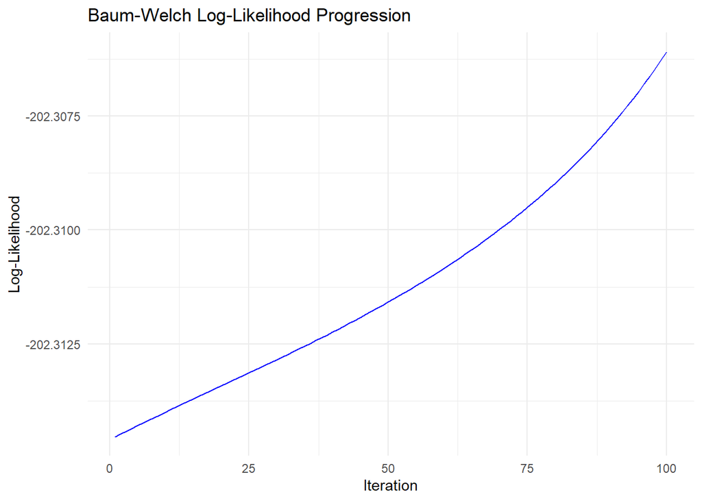

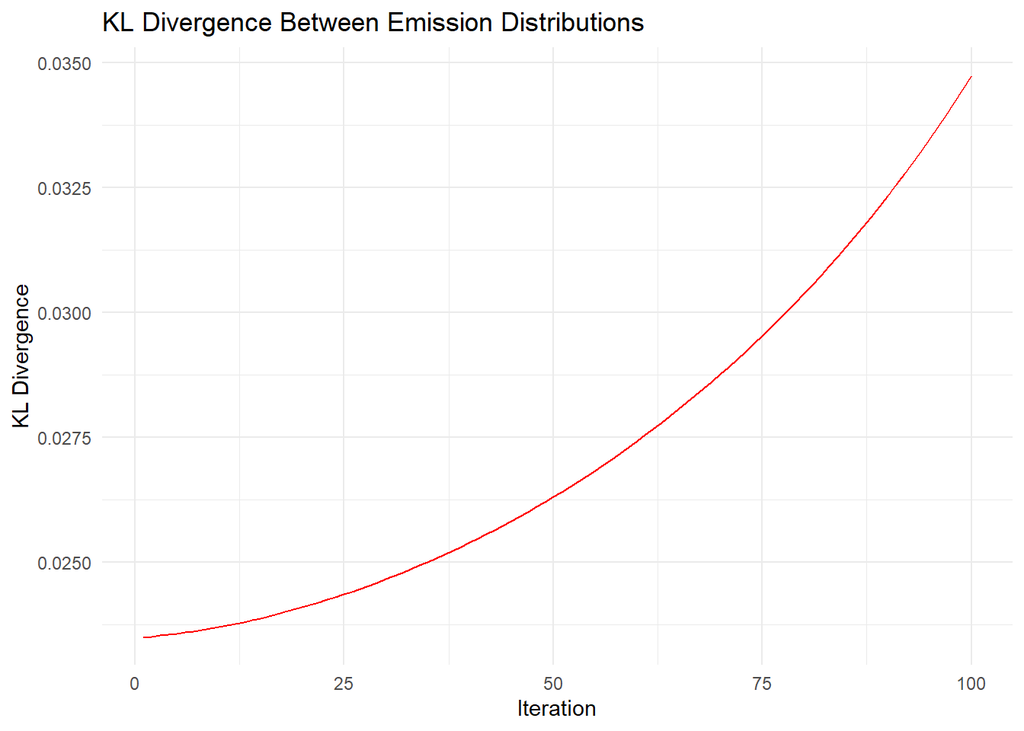

```r
library(ggplot2) #note default colab lib

# Testing the implementation
data = scan("https://liangfgithub.github.io/Data/coding4_part2_data.txt", what=integer(), quiet=TRUE)
mz = 2
mx = 3

w = c(0.5, 0.5)
A = matrix(c(0.5, 0.5, 0.5, 0.5), nrow=2, byrow=TRUE)
B = matrix(c(1/9, 3/9, 5/9, 1/6, 2/6, 3/6), nrow=2, byrow=TRUE)

# Running Baum-Welch for 100 iterations
result = myBW(data, A, B, w, iterations=100)
```

```r
# Running Viterbi Algorithm
Z = myViterbi(data, mx, mz, w, result$A, result$B)
cat("\nMost likely sequence of hidden states (Viterbi):\n")
```

```
##
## Most likely sequence of hidden states (Viterbi):
```

```r
print(Z)
```

```
##   [1] 1 1 1 1 1 1 1 2 1 1 1 1 1 2 2 1 1 1 1 1 1 1 2 2 2 2 2 1 1 1 1 1 1 1 2 1 1
##  [38] 1 1 1 1 1 1 2 2 1 1 1 1 1 1 2 2 2 1 1 1 1 2 2 2 2 1 1 1 1 1 1 1 1 2 2 2 2
##  [75] 2 2 2 2 2 2 2 2 2 2 2 2 2 2 2 2 2 1 1 1 1 2 1 1 1 1 1 1 1 1 1 1 1 1 1 2 1
## [112] 1 1 1 2 1 1 1 1 1 1 2 2 2 2 2 2 2 2 2 2 2 2 1 1 1 1 1 1 1 2 2 2 2 2 2 2 2
## [149] 2 2 2 1 1 1 2 2 2 2 2 2 1 1 1 1 1 2 2 2 2 2 2 2 2 2 1 1 1 2 2 2 1 1 1 1 1
## [186] 1 1 1 2 2 2 2 2 1 1 1 1 1 1 1
```

```r
# Load benchmark Z for evaluation
benchmark_Z = scan("https://liangfgithub.github.io/Data/Coding4_part2_Z.txt", what=integer(), quiet=TRUE)

# Comparison with benchmark Z
evaluate_viterbi = function(Z_computed, Z_benchmark) {
  if (length(Z_computed) != length(Z_benchmark)) {
    cat("Length mismatch between computed and benchmark Z sequences.\n")
    return(NULL)
  }
  accuracy = sum(Z_computed == Z_benchmark) / length(Z_computed) * 100
  cat(sprintf("Viterbi Sequence Accuracy: %.3f%%\n", accuracy))
}

# Evaluate Viterbi output
cat("\nEvaluating Viterbi Output:\n")
```

```
##
## Evaluating Viterbi Output:
```

```r
evaluate_viterbi(Z, benchmark_Z)
```

```
## Viterbi Sequence Accuracy: 100.000%
```

## Part II: Testing part II:

2. Initialize matrix B such that each entry is 1/3, and run your Baum-Welch algorithm for 20 and 100 iterations. Examine the resulting A and B matrices, and explain why you obtained these outcomes. Based on your findings, you should understand why we cannot initialize our parameters in a way that makes the latent states indistinguishable.

```r
# Initialize matrix B uniformly and run Baum-Welch for 20 and 100 iterations
B_uniform = matrix(1/3, nrow=mz, ncol=mx)

# Running Baum-Welch for 20 iterations with uniform B
cat("\nRunning Baum-Welch with Uniform Emission Matrix B (1/3) for 20 iterations:\n")
```

```
##
## Running Baum-Welch with Uniform Emission Matrix B (1/3) for 20 iterations:
```

```r
result_20 = myBW(data, A, B_uniform, w, iterations=20)
```

```
##
## Iteration 20: Evaluating against expected values
## Transition Matrix A:
##      [,1]  [,2]
## [1,] "0.5" "0.5"
## [2,] "0.5" "0.5"
## Expected Transition Matrix A:
##      [,1]         [,2]
## [1,] "0.49793938" "0.50206062"
## [2,] "0.44883431" "0.55116569"
## Emission Matrix B:
##      [,1]    [,2]    [,3]
## [1,] "0.285" "0.190" "0.525"
## [2,] "0.285" "0.190" "0.525"
## Expected Emission Matrix B:
##      [,1]         [,2]         [,3]
## [1,] "0.22159897" "0.20266127" "0.57573976"
## [2,] "0.34175148" "0.17866665" "0.47958186"
##
## Accuracy of Transition Matrix A: 97.41%
## Accuracy of Emission Matrix B: 96.15%
```

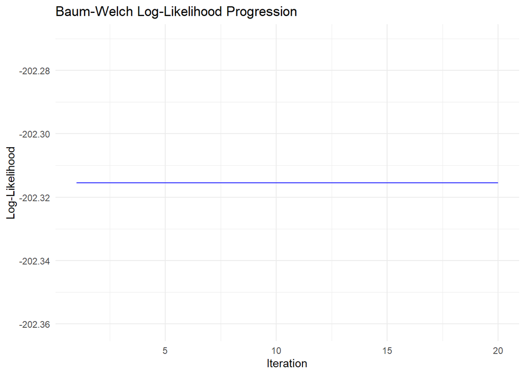

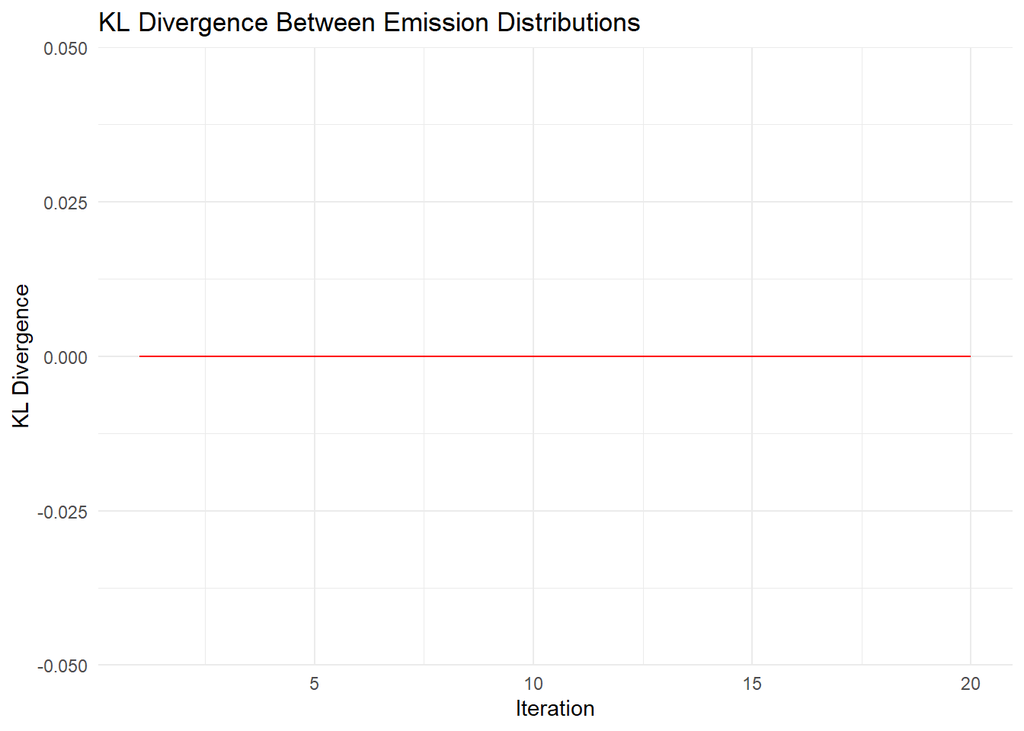

```r
# Running Baum-Welch for 100 iterations with uniform B
cat("\nRunning Baum-Welch with Uniform Emission Matrix B (1/3) for 100 iterations:\n")
```

```
##
## Running Baum-Welch with Uniform Emission Matrix B (1/3) for 100 iterations:
```

```r
result_100 = myBW(data, A, B_uniform, w, iterations=100)
```

```
##
## Iteration 100: Evaluating against expected values
## Transition Matrix A:
##      [,1]  [,2]
## [1,] "0.5" "0.5"
## [2,] "0.5" "0.5"
## Expected Transition Matrix A:
##      [,1]         [,2]
## [1,] "0.49793938" "0.50206062"
## [2,] "0.44883431" "0.55116569"
## Emission Matrix B:
##      [,1]    [,2]    [,3]
## [1,] "0.285" "0.190" "0.525"
## [2,] "0.285" "0.190" "0.525"
## Expected Emission Matrix B:
##      [,1]         [,2]         [,3]
## [1,] "0.22159897" "0.20266127" "0.57573976"
## [2,] "0.34175148" "0.17866665" "0.47958186"
##
## Accuracy of Transition Matrix A: 97.41%
## Accuracy of Emission Matrix B: 96.15%
```

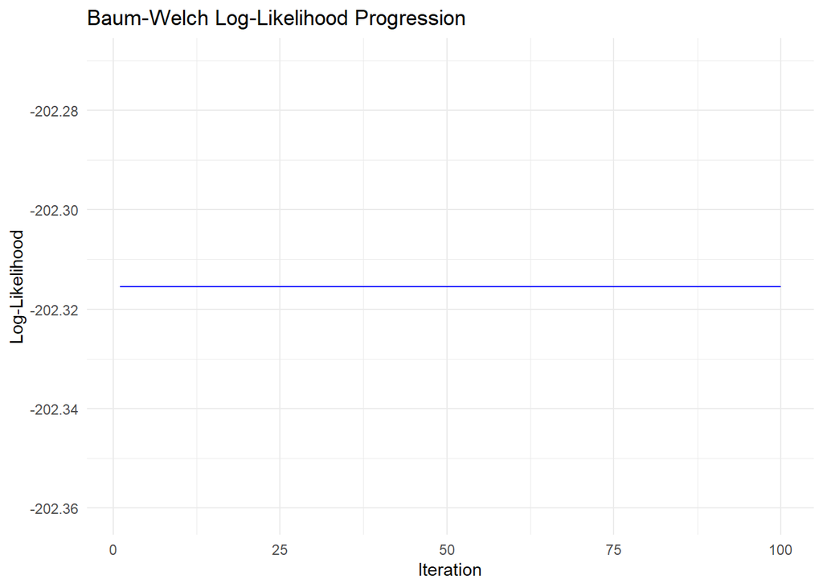

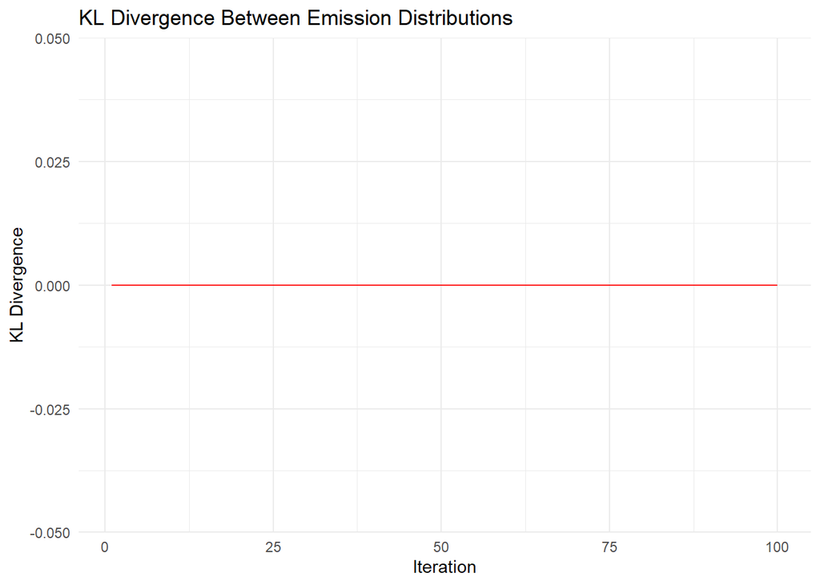

When initializing matrix B such that each entry is 1/3, the Baum-Welch algorithm tends to converge more slowly or may not converge to a meaningful solution even after many iterations. This occurs because the uniform initialization makes the latent states indistinguishable. The emission probabilities are the same for all states, so the observed data does not initially provide any basis to differentiate between states.

In the Baum-Welch algorithms(an Expectation Maximization algorithm), the initial parameter values significantly influence the convergence path. When latent states are indistinct, the algorithm may get stuck in a local maximum of the likelihood function where the states remain undifferentiated. This happens because the likelihood has a flat region due to the symmetry in the initial parameters, and the algorithm lacks the gradient information needed to move towards the global maximum.

The Log-Likelihood progression plot shows this with the given B matrix showing a gradual increase over iterations, indicating that the model is learning. This is in contrast to the plot when B is initialized uniformly with 1/3 which gives a log-likelihood plot that is entirely flat, demonstrating that the algorithm is not making progress in improving the model.

To further illustrate this point, the Kullback-Leibler(KL) divergence between the emission distributions of the latent states was plotted. This measures how one probability ditribution diverges from a second, expected probability distribution, effectively quantifying how distinguishable the emission probabilities of the states are. When B is initialized uniformly the initial KL divergence between the emission distributions is near 0 which indicates that the states are indistinguishable. As the algorithm progresses since it cannot differentiate states the KL divergence remains low over iterations. This is different when B is initialized with distinct emission probabilities since the initial KL divergence is higher the states are already somewhat distinguishable. As the algorithm progresses the KL divergence is expected to increase or stabilize at a higher level indicating that the emission distributions of the latent states are becoming more distinct. This rising/stable KL divergence would demonstrate that the algorithm is effectively learning from the data and nehancing the diferentiation between states.

The point surrounding the Log-Likelihood progression plot indicating whether or not one’s implementation is correct and also showcasing why uniformly initializing was taken from [StackOverflow](https://stats.stackexchange.com/questions/513563/how-do-i-check-my-own-baum-welch-algorithm)

Additionally Chapters 13.2 of *Pattern Recognition and Machine Learning by Christopher M. Bishop, 2009* and *Chapter 8.5 of ESL*(notably figure 8.6), was consulted to verify the log-likelihood tracking claim above and Chapters 8.7.2 and 6.2 of Probabilistic Machine Learning by Kevin P. Murphy, 2022 provide a reason to add the KL divergence tracking across iterations.

```r
# Running Baum-Welch for 1000 iterations with uniform B
cat("\nRunning Baum-Welch with Uniform Emission Matrix B (1/3) for 1000 iterations:\n")
```

```
##
## Running Baum-Welch with Uniform Emission Matrix B (1/3) for 1000 iterations:
```

```r
result_1000 = myBW(data, A, B_uniform, w, iterations=1000)
```

```
##
## Iteration 1000: Evaluating against expected values
## Transition Matrix A:
##      [,1]  [,2]
## [1,] "0.5" "0.5"
## [2,] "0.5" "0.5"
## Expected Transition Matrix A:
##      [,1]         [,2]
## [1,] "0.49793938" "0.50206062"
## [2,] "0.44883431" "0.55116569"
## Emission Matrix B:
##      [,1]    [,2]    [,3]
## [1,] "0.285" "0.190" "0.525"
## [2,] "0.285" "0.190" "0.525"
## Expected Emission Matrix B:
##      [,1]         [,2]         [,3]
## [1,] "0.22159897" "0.20266127" "0.57573976"
## [2,] "0.34175148" "0.17866665" "0.47958186"
##
## Accuracy of Transition Matrix A: 97.41%
## Accuracy of Emission Matrix B: 96.15%
```

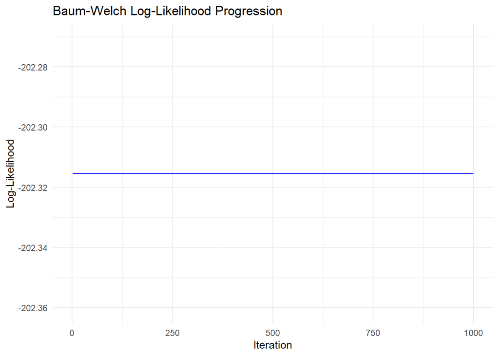

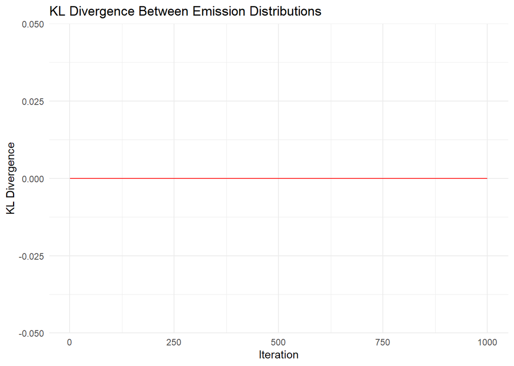

```r
cat("\nRunning Baum-Welch with Given Emission Matrix B for 3000 iterations:\n")
```

```
##
## Running Baum-Welch with Given Emission Matrix B for 3000 iterations:
```

```r
# Running Baum-Welch for 3000 iterations
result = myBW(data, A, B, w, iterations=3000)
```

```
##
## Iteration 3000: Evaluating against expected values
## Transition Matrix A:
##      [,1]         [,2]
## [1,] "0.76354533" "0.23645467"
## [2,] "0.57065802" "0.42934198"
## Expected Transition Matrix A:
##      [,1]         [,2]
## [1,] "0.49793938" "0.50206062"
## [2,] "0.44883431" "0.55116569"
## Emission Matrix B:
##      [,1]            [,2]            [,3]
## [1,] "2.2085179e-01" "3.3264357e-02" "7.4588385e-01"
## [2,] "4.3746841e-01" "5.6253159e-01" "3.4049846e-23"
## Expected Emission Matrix B:
##      [,1]         [,2]         [,3]
## [1,] "0.22159897" "0.20266127" "0.57573976"
## [2,] "0.34175148" "0.17866665" "0.47958186"
##
## Accuracy of Transition Matrix A: 83.77%
## Accuracy of Emission Matrix B: 82.20%
```

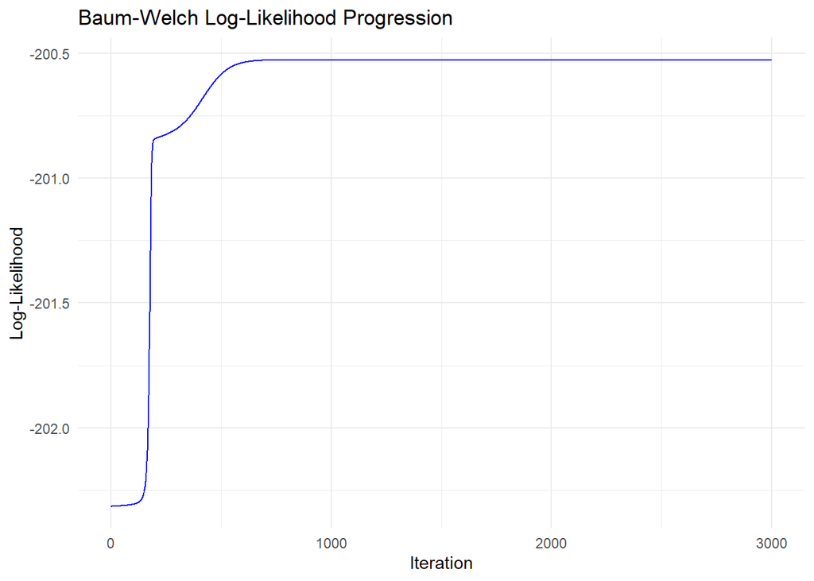

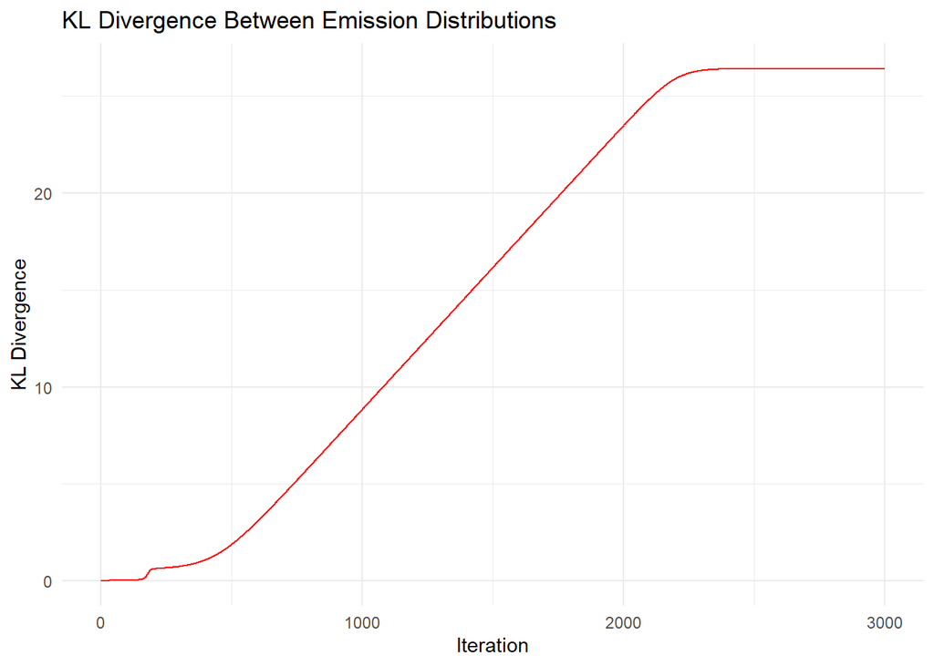

Result shows, even increasing the number of iterations 10 times will lead to the same matrices as 100 iterations.